# Data Wrangling - Which pitching stats correlate most with wins?

In major league baseball, you can't win without pitching, but which pitching stats correlate most with wins? In this project, I will be looking at three pitching stats (walks, strikeouts and hits), and try to find which of them impacted wins the most for the 2021-2024 seasons for the New York Mets. I will be using pitching stats downloaded directly from Fangraphs and their win-loss record will be acquired programmatically using the Python package `pybaseball`.

#### **Dataset 1**

Type: Python Dataframe

Method: This data was acquired using the Python package `pybaseball`. I used `pybaseball` because it has many functions that scrape various baseball data sites, making it easy to find something like game by game win-loss records over multiple seasons.

Dataset variables:

- Date : Date of game
- Tm : Team
- Home_Away : Whether the team is home or away
- Opp : Opponent
- W/L : Wins or Loss
- R : Runs scored
- RA: Runs allowed
- Inn : Total innings
- W-L : Overall team record
- Rank : Divisional Rank
- GB : Games behind in the division
- Win : Winning pitcher
- Loss : Losing pitcher
- Save : Pitcher with a save
- Time : Game time
- D/N : Day or night game
- Attendance : Game attendance
- cLI : Championship Leverage Index
- Orig. Scheduled

```python
# !pip install pybaseball  # uncomment to install pybaseball package if needed
from pybaseball import schedule_and_record
import pandas as pd

games = pd.DataFrame()

for i in range(2021,2025):    # set the range for the years
    team = "NYM"
    year = i
    game_log = schedule_and_record(year, team)
    game_log['Date'] = game_log['Date'] + ', ' + str(i)    # add the year to the end of the date column
    games=pd.concat([games, game_log], ignore_index = True)    # add the new table to the original

display(games.head())
display(games.tail())
```

|  | Date | Tm | Home_Away | Opp | W/L | R | RA | Inn | W-L | Rank | GB | Win | Loss | Save | Time | D/N | Attendance | cLI | Streak | Orig. Scheduled |
| --- | --- | --- | --- | --- | --- | --- | --- | --- | --- | --- | --- | --- | --- | --- | --- | --- | --- | --- | --- | --- |
| 0 | Monday, Apr 5, 2021 | NYM | @ | PHI | L | 3.0 | 5.0 | 9.0 | 0-1 | 3.0 | 2.5 | Brogdon | May | Alvarado | 3:15 | N | 10782.0 | 1.09 | -1 | None |
| 1 | Tuesday, Apr 6, 2021 | NYM | @ | PHI | W | 8.0 | 4.0 | 9.0 | 1-1 | 3.0 | 1.5 | Stroman | Anderson | None | 3:40 | N | 10752.0 | 1.08 | 1 | None |
| 2 | Wednesday, Apr 7, 2021 | NYM | @ | PHI | L | 2.0 | 8.0 | 9.0 | 1-2 | 2.0 | 2.5 | Brogdon | Peterson | None | 3:35 | D | 10807.0 | 1.14 | -1 | None |
| 3 | Thursday, Apr 8, 2021 | NYM | Home | MIA | W-wo | 3.0 | 2.0 | 9.0 | 2-2 | 2.0 | 2.0 | Díaz | Bass | None | 3:18 | D | 8492.0 | 1.00 | 1 | None |
| 4 | Saturday, Apr 10, 2021 | NYM | Home | MIA | L | 0.0 | 3.0 | 9.0 | 2-3 | 3.0 | 1.5 | Rogers | deGrom | García | 2:36 | D | 8419.0 | 1.10 | -1 | None |

|  | Date | Tm | Home_Away | Opp | W/L | R | RA | Inn | W-L | Rank | GB | Win | Loss | Save | Time | D/N | Attendance | cLI | Streak | Orig. Scheduled |
| --- | --- | --- | --- | --- | --- | --- | --- | --- | --- | --- | --- | --- | --- | --- | --- | --- | --- | --- | --- | --- |
| 643 | Friday, Sep 27, 2024 | NYM | @ | MIL | L | 4.0 | 8.0 | 9.0 | 87-71 | 2.0 | 6.0 | Ross | Manaea | Megill | 3:05 | N | 33996.0 | 2.24 | -2 | None |
| 644 | Saturday, Sep 28, 2024 | NYM | @ | MIL | L | 0.0 | 6.0 | 9.0 | 87-72 | 3.0 | 6.0 | Myers | Quintana | None | 2:31 | N | 39637.0 | 2.70 | -3 | None |
| 645 | Sunday, Sep 29, 2024 | NYM | @ | MIL | W | 5.0 | 0.0 | 9.0 | 88-72 | 2.0 | 6.0 | Peterson | Rea | None | 2:34 | D | 33754.0 | 3.59 | 1 | None |
| 646 | Monday, Sep 30 (1), 2024 | NYM | @ | ATL | W | 8.0 | 7.0 | 9.0 | 89-72 | 2.0 | 6.0 | Díaz | Johnson | None | 2:58 | D | NaN | 4.78 | 2 | None |
| 647 | Monday, Sep 30 (2), 2024 | NYM | @ | ATL | L | 0.0 | 3.0 | 9.0 | 89-73 | 2.0 | 6.0 | Hernández | Lucchesi | Iglesias | 2:14 | D | 41561.0 | -.21 | -1 | None |

#### Dataset 2

Type: CSV

Method: I downloaded the CSV file directly from the Fangraphs website. I chose Fangraphs because it has the most comprehensive and customizable statistics, allowing me to find the game level data I needed.

Dataset variables:

- Date : Date of game
- Name : Pitcher's name
- Tm : Team
- G : Games played
- TBF : Total batters faced
- ERA : Earned run average
- H : Hits
- 2B : Doubles
- 3B : Triples
- R : Runs
- ER : Earned Runs
- HR : Home Runs
- BB : Walks
- IBB : Intentional Walks
- HBP : Hit by pitches
- AVG : Batting average
- OBP : On base percentage
- SLG : Slugging percentage
- wOBA : Weighted on base average
- playerID : Player's MLB ID number

```python
pitching = pd.read_csv('nym_pitching_stats.csv')
display(pitching.head())
display(pitching.tail())
```

|  | Date | Name | Tm | G | TBF | ERA | H | 2B | 3B | R | ... | HR | BB | IBB | HBP | SO | AVG | OBP | SLG | wOBA | playerId |
| --- | --- | --- | --- | --- | --- | --- | --- | --- | --- | --- | --- | --- | --- | --- | --- | --- | --- | --- | --- | --- | --- |
| 0 | 2021-04-05 | Trevor May | NYM | 1 | 4 | 54.000001 | 2 | 0 | 0 | 3 | ... | 0 | 1 | 0 | 0 | 1 | 0.666667 | 0.750000 | 0.666667 | 0.612457 | 6398 |
| 1 | 2021-04-05 | Aaron Loup | NYM | 1 | 5 | 0.000000 | 1 | 0 | 0 | 2 | ... | 0 | 0 | 0 | 1 | 0 | 0.333333 | 0.400000 | 0.333333 | 0.320198 | 10343 |
| 2 | 2021-04-05 | Jacob deGrom | NYM | 1 | 21 | 0.000000 | 3 | 1 | 0 | 0 | ... | 0 | 2 | 0 | 0 | 7 | 0.157895 | 0.238095 | 0.210526 | 0.208723 | 10954 |
| 3 | 2021-04-05 | Miguel Castro | NYM | 1 | 4 | 0.000000 | 1 | 0 | 0 | 0 | ... | 0 | 0 | 0 | 0 | 0 | 0.250000 | 0.250000 | 0.250000 | 0.219764 | 15684 |
| 4 | 2021-04-06 | Jeurys Familia | NYM | 1 | 6 | 9.000000 | 2 | 1 | 0 | 2 | ... | 0 | 1 | 0 | 0 | 1 | 0.400000 | 0.500000 | 0.600000 | 0.468736 | 5114 |

5 rows × 21 columns

|  | Date | Name | Tm | G | TBF | ERA | H | 2B | 3B | R | ... | HR | BB | IBB | HBP | SO | AVG | OBP | SLG | wOBA | playerId |
| --- | --- | --- | --- | --- | --- | --- | --- | --- | --- | --- | --- | --- | --- | --- | --- | --- | --- | --- | --- | --- | --- |
| 2706 | 2024-09-30 | Adam Ottavino | NYM | 1 | 3 | 0.000000 | 0 | 0 | 0 | 0 | ... | 0 | 0 | 0 | 0 | 1 | 0.000000 | 0.000000 | 0.000000 | 0.000000 | 1247 |
| 2707 | 2024-09-30 | Huascar Brazoban | NYM | 1 | 2 | 0.000000 | 0 | 0 | 0 | 0 | ... | 0 | 1 | 0 | 0 | 0 | 0.000000 | 0.500000 | 0.000000 | 0.344565 | 6107 |
| 2708 | 2024-09-30 | Edwin Diaz | NYM | 1 | 9 | 10.800000 | 3 | 1 | 0 | 2 | ... | 0 | 1 | 0 | 0 | 2 | 0.375000 | 0.444444 | 0.500000 | 0.411889 | 14710 |
| 2709 | 2024-09-30 | Phil Maton | NYM | 1 | 3 | 54.000001 | 1 | 0 | 0 | 2 | ... | 0 | 0 | 0 | 1 | 0 | 0.500000 | 0.666667 | 0.500000 | 0.533968 | 18064 |
| 2710 | 2024-09-30 | Tylor Megill | NYM | 1 | 26 | 4.764706 | 8 | 0 | 0 | 3 | ... | 2 | 2 | 0 | 0 | 8 | 0.333333 | 0.384615 | 0.583333 | 0.414144 | 21318 |

5 rows × 21 columns

### Quality Issue 1: Consistency - Remove doubleheaders

```python
display(games.tail())
```

|  | Date | Tm | Home_Away | Opp | W/L | R | RA | Inn | W-L | Rank | GB | Win | Loss | Save | Time | D/N | Attendance | cLI | Streak | Orig. Scheduled |
| --- | --- | --- | --- | --- | --- | --- | --- | --- | --- | --- | --- | --- | --- | --- | --- | --- | --- | --- | --- | --- |
| 643 | Friday, Sep 27, 2024 | NYM | @ | MIL | L | 4.0 | 8.0 | 9.0 | 87-71 | 2.0 | 6.0 | Ross | Manaea | Megill | 3:05 | N | 33996.0 | 2.24 | -2 | None |
| 644 | Saturday, Sep 28, 2024 | NYM | @ | MIL | L | 0.0 | 6.0 | 9.0 | 87-72 | 3.0 | 6.0 | Myers | Quintana | None | 2:31 | N | 39637.0 | 2.70 | -3 | None |
| 645 | Sunday, Sep 29, 2024 | NYM | @ | MIL | W | 5.0 | 0.0 | 9.0 | 88-72 | 2.0 | 6.0 | Peterson | Rea | None | 2:34 | D | 33754.0 | 3.59 | 1 | None |
| 646 | Monday, Sep 30 (1), 2024 | NYM | @ | ATL | W | 8.0 | 7.0 | 9.0 | 89-72 | 2.0 | 6.0 | Díaz | Johnson | None | 2:58 | D | NaN | 4.78 | 2 | None |
| 647 | Monday, Sep 30 (2), 2024 | NYM | @ | ATL | L | 0.0 | 3.0 | 9.0 | 89-73 | 2.0 | 6.0 | Hernández | Lucchesi | Iglesias | 2:14 | D | 41561.0 | -.21 | -1 | None |

```python
display(games[games['Date'].str.contains('Monday, Sep 30')])
display(pitching[pitching['Date'].str.contains('2024-09-30')])
```

|  | Date | Tm | Home_Away | Opp | W/L | R | RA | Inn | W-L | Rank | GB | Win | Loss | Save | Time | D/N | Attendance | cLI | Streak | Orig. Scheduled |
| --- | --- | --- | --- | --- | --- | --- | --- | --- | --- | --- | --- | --- | --- | --- | --- | --- | --- | --- | --- | --- |
| 646 | Monday, Sep 30 (1), 2024 | NYM | @ | ATL | W | 8.0 | 7.0 | 9.0 | 89-72 | 2.0 | 6.0 | Díaz | Johnson | None | 2:58 | D | NaN | 4.78 | 2 | None |
| 647 | Monday, Sep 30 (2), 2024 | NYM | @ | ATL | L | 0.0 | 3.0 | 9.0 | 89-73 | 2.0 | 6.0 | Hernández | Lucchesi | Iglesias | 2:14 | D | 41561.0 | -.21 | -1 | None |

|  | Date | Name | Tm | G | TBF | ERA | H | 2B | 3B | R | ... | HR | BB | IBB | HBP | SO | AVG | OBP | SLG | wOBA | playerId |
| --- | --- | --- | --- | --- | --- | --- | --- | --- | --- | --- | --- | --- | --- | --- | --- | --- | --- | --- | --- | --- | --- |
| 2703 | 2024-09-30 | Adam Ottavino | NYM | 1 | 3 | 0.000000 | 0 | 0 | 0 | 0 | ... | 0 | 0 | 0 | 0 | 1 | 0.000000 | 0.000000 | 0.000000 | 0.000000 | 1247 |
| 2704 | 2024-09-30 | Huascar Brazoban | NYM | 1 | 6 | 18.000000 | 3 | 0 | 0 | 2 | ... | 0 | 1 | 0 | 0 | 1 | 0.600000 | 0.666667 | 0.600000 | 0.555710 | 6107 |
| 2705 | 2024-09-30 | Joey Lucchesi | NYM | 1 | 25 | 1.500000 | 3 | 2 | 0 | 1 | ... | 0 | 4 | 0 | 0 | 5 | 0.142857 | 0.280000 | 0.238095 | 0.245885 | 19320 |
| 2706 | 2024-09-30 | Adam Ottavino | NYM | 1 | 3 | 0.000000 | 0 | 0 | 0 | 0 | ... | 0 | 0 | 0 | 0 | 1 | 0.000000 | 0.000000 | 0.000000 | 0.000000 | 1247 |
| 2707 | 2024-09-30 | Huascar Brazoban | NYM | 1 | 2 | 0.000000 | 0 | 0 | 0 | 0 | ... | 0 | 1 | 0 | 0 | 0 | 0.000000 | 0.500000 | 0.000000 | 0.344565 | 6107 |
| 2708 | 2024-09-30 | Edwin Diaz | NYM | 1 | 9 | 10.800000 | 3 | 1 | 0 | 2 | ... | 0 | 1 | 0 | 0 | 2 | 0.375000 | 0.444444 | 0.500000 | 0.411889 | 14710 |
| 2709 | 2024-09-30 | Phil Maton | NYM | 1 | 3 | 54.000001 | 1 | 0 | 0 | 2 | ... | 0 | 0 | 0 | 1 | 0 | 0.500000 | 0.666667 | 0.500000 | 0.533968 | 18064 |
| 2710 | 2024-09-30 | Tylor Megill | NYM | 1 | 26 | 4.764706 | 8 | 0 | 0 | 3 | ... | 2 | 2 | 0 | 0 | 8 | 0.333333 | 0.384615 | 0.583333 | 0.414144 | 21318 |

8 rows × 21 columns

Issue and justification: A doubleheader is when teams play two games in one day. The `games` dataframe differentiates these games with a `(1)` or `(2)`. The `pitching` table does not and records the stats for both games as one single date. In my initial assessment, I noticed a doubleheader in the `tail` of `games`. I then checked for that date in both dataframes to see how each one handles it.

### Quality Issue 2: Consistency - Multiple values for "Win" and "Loss"

```python
games.sample(10, random_state=5)
```

|  | Date | Tm | Home_Away | Opp | W/L | R | RA | Inn | W-L | Rank | GB | Win | Loss | Save | Time | D/N | Attendance | cLI | Streak | Orig. Scheduled |
| --- | --- | --- | --- | --- | --- | --- | --- | --- | --- | --- | --- | --- | --- | --- | --- | --- | --- | --- | --- | --- |
| 129 | Saturday, Aug 28, 2021 | NYM | Home | WSN | W | 5.0 | 3.0 | 9.0 | 63-67 | 3.0 | 6.5 | May | Harper | Díaz | 3:02 | N | 27870.0 | .27 | 1 | None |
| 140 | Thursday, Sep 9, 2021 | NYM | @ | MIA | L | 2.0 | 3.0 | 9.0 | 70-71 | 3.0 | 4.5 | Bleier | Familia | Floro | 2:59 | N | 8075.0 | 1.08 | -2 | None |
| 326 | Saturday, Apr 1, 2023 | NYM | @ | MIA | W | 6.0 | 2.0 | 9.0 | 2-1 | 2.0 | 0.5 | Megill | Nardi | None | 2:54 | D | 14695.0 | 1.01 | 1 | None |
| 328 | Monday, Apr 3, 2023 | NYM | @ | MIL | L | 0.0 | 10.0 | 9.0 | 3-2 | 2.0 | 0.5 | Peralta | Carrasco | Wilson | 2:37 | D | 42017.0 | 1.09 | -1 | None |
| 563 | Wednesday, Jun 26, 2024 | NYM | Home | NYY | W | 12.0 | 2.0 | 9.0 | 39-39 | 3.0 | 13.0 | Manaea | Gil | Houser | 3:05 | N | 43004.0 | .67 | 3 | None |
| 617 | Tuesday, Aug 27, 2024 | NYM | @ | ARI | W | 8.0 | 3.0 | 9.0 | 69-63 | 3.0 | 9.0 | Manaea | Pfaadt | None | 2:51 | N | 22575.0 | .89 | 1 | None |
| 643 | Friday, Sep 27, 2024 | NYM | @ | MIL | L | 4.0 | 8.0 | 9.0 | 87-71 | 2.0 | 6.0 | Ross | Manaea | Megill | 3:05 | N | 33996.0 | 2.24 | -2 | None |
| 627 | Saturday, Sep 7, 2024 | NYM | Home | CIN | W | 4.0 | 0.0 | 9.0 | 78-64 | 2.0 | 7.0 | Quintana | Moll | None | 2:26 | D | 34048.0 | 1.41 | 9 | None |
| 72 | Saturday, Jun 26, 2021 | NYM | Home | PHI | W-wo | 4.0 | 3.0 | 9.0 | 41-32 | 1.0 | up 5.5 | Díaz | Neris | None | 3:05 | D | 29205.0 | 1.89 | 1 | None |
| 123 | Saturday, Aug 21, 2021 | NYM | @ | LAD | L | 3.0 | 4.0 | 9.0 | 61-63 | 3.0 | 6.0 | Scherzer | Hill | Jansen | 3:16 | D | 44783.0 | .65 | -3 | None |

```python
games['W/L'].value_counts().reset_index()
```

|  | W/L | count |
| --- | --- | --- |
| 0 | W | 307 |
| 1 | L | 283 |
| 2 | W-wo | 35 |
| 3 | L-wo | 23 |

Issue and justification: The `W/L` column in `games` has two values for wins (`W` and `W-wo`) and two values for losses (`L` and `L-wo`). I used a random sample to see these differences in the dataframe, and checked the `value_counts` of the column to confirm.

### Tidiness Issue 1: Dates in different formats

```python
display(games.head())
display(pitching.head())
```

|  | Date | Tm | Home_Away | Opp | W/L | R | RA | Inn | W-L | Rank | GB | Win | Loss | Save | Time | D/N | Attendance | cLI | Streak | Orig. Scheduled |
| --- | --- | --- | --- | --- | --- | --- | --- | --- | --- | --- | --- | --- | --- | --- | --- | --- | --- | --- | --- | --- |
| 0 | Monday, Apr 5, 2021 | NYM | @ | PHI | L | 3.0 | 5.0 | 9.0 | 0-1 | 3.0 | 2.5 | Brogdon | May | Alvarado | 3:15 | N | 10782.0 | 1.09 | -1 | None |
| 1 | Tuesday, Apr 6, 2021 | NYM | @ | PHI | W | 8.0 | 4.0 | 9.0 | 1-1 | 3.0 | 1.5 | Stroman | Anderson | None | 3:40 | N | 10752.0 | 1.08 | 1 | None |
| 2 | Wednesday, Apr 7, 2021 | NYM | @ | PHI | L | 2.0 | 8.0 | 9.0 | 1-2 | 2.0 | 2.5 | Brogdon | Peterson | None | 3:35 | D | 10807.0 | 1.14 | -1 | None |
| 3 | Thursday, Apr 8, 2021 | NYM | Home | MIA | W-wo | 3.0 | 2.0 | 9.0 | 2-2 | 2.0 | 2.0 | Díaz | Bass | None | 3:18 | D | 8492.0 | 1.00 | 1 | None |
| 4 | Saturday, Apr 10, 2021 | NYM | Home | MIA | L | 0.0 | 3.0 | 9.0 | 2-3 | 3.0 | 1.5 | Rogers | deGrom | García | 2:36 | D | 8419.0 | 1.10 | -1 | None |

|  | Date | Name | Tm | G | TBF | ERA | H | 2B | 3B | R | ... | HR | BB | IBB | HBP | SO | AVG | OBP | SLG | wOBA | playerId |
| --- | --- | --- | --- | --- | --- | --- | --- | --- | --- | --- | --- | --- | --- | --- | --- | --- | --- | --- | --- | --- | --- |
| 0 | 2021-04-05 | Trevor May | NYM | 1 | 4 | 54.000001 | 2 | 0 | 0 | 3 | ... | 0 | 1 | 0 | 0 | 1 | 0.666667 | 0.750000 | 0.666667 | 0.612457 | 6398 |
| 1 | 2021-04-05 | Aaron Loup | NYM | 1 | 5 | 0.000000 | 1 | 0 | 0 | 2 | ... | 0 | 0 | 0 | 1 | 0 | 0.333333 | 0.400000 | 0.333333 | 0.320198 | 10343 |
| 2 | 2021-04-05 | Jacob deGrom | NYM | 1 | 21 | 0.000000 | 3 | 1 | 0 | 0 | ... | 0 | 2 | 0 | 0 | 7 | 0.157895 | 0.238095 | 0.210526 | 0.208723 | 10954 |
| 3 | 2021-04-05 | Miguel Castro | NYM | 1 | 4 | 0.000000 | 1 | 0 | 0 | 0 | ... | 0 | 0 | 0 | 0 | 0 | 0.250000 | 0.250000 | 0.250000 | 0.219764 | 15684 |
| 4 | 2021-04-06 | Jeurys Familia | NYM | 1 | 6 | 9.000000 | 2 | 1 | 0 | 2 | ... | 0 | 1 | 0 | 0 | 1 | 0.400000 | 0.500000 | 0.600000 | 0.468736 | 5114 |

5 rows × 21 columns

```python
display(games['Date'].value_counts().reset_index())
display(pitching['Date'].value_counts().reset_index())
```

|  | Date | count |
| --- | --- | --- |
| 0 | Monday, Apr 5, 2021 | 1 |
| 1 | Thursday, Aug 17, 2023 | 1 |
| 2 | Saturday, Jul 29, 2023 | 1 |
| 3 | Sunday, Jul 30, 2023 | 1 |
| 4 | Tuesday, Aug 1, 2023 | 1 |
| ... | ... | ... |
| 643 | Sunday, Jun 5, 2022 | 1 |
| 644 | Monday, Jun 6, 2022 | 1 |
| 645 | Tuesday, Jun 7, 2022 | 1 |
| 646 | Wednesday, Jun 8, 2022 | 1 |
| 647 | Monday, Sep 30 (2), 2024 | 1 |

648 rows × 2 columns

|  | Date | count |
| --- | --- | --- |
| 0 | 2024-04-04 | 10 |
| 1 | 2022-08-20 | 9 |
| 2 | 2021-09-28 | 9 |
| 3 | 2022-05-17 | 9 |
| 4 | 2022-05-21 | 9 |
| ... | ... | ... |
| 610 | 2022-06-14 | 2 |
| 611 | 2023-05-15 | 2 |
| 612 | 2024-08-17 | 1 |
| 613 | 2023-04-28 | 1 |
| 614 | 2021-04-23 | 1 |

615 rows × 2 columns

Issue and justification: Since I will be merging on the `Date` column it is important that the dates of the two dataframes are in the same format. I checked the heads of both tables, and used `value_counts` to confirm the differences in format.

### Tidiness Issue 2: "W/L" should be changed from categorical to numeric for analysis

```python
games.head()
```

|  | Date | Tm | Home_Away | Opp | W/L | R | RA | Inn | W-L | Rank | GB | Win | Loss | Save | Time | D/N | Attendance | cLI | Streak | Orig. Scheduled |
| --- | --- | --- | --- | --- | --- | --- | --- | --- | --- | --- | --- | --- | --- | --- | --- | --- | --- | --- | --- | --- |
| 0 | Monday, Apr 5, 2021 | NYM | @ | PHI | L | 3.0 | 5.0 | 9.0 | 0-1 | 3.0 | 2.5 | Brogdon | May | Alvarado | 3:15 | N | 10782.0 | 1.09 | -1 | None |
| 1 | Tuesday, Apr 6, 2021 | NYM | @ | PHI | W | 8.0 | 4.0 | 9.0 | 1-1 | 3.0 | 1.5 | Stroman | Anderson | None | 3:40 | N | 10752.0 | 1.08 | 1 | None |
| 2 | Wednesday, Apr 7, 2021 | NYM | @ | PHI | L | 2.0 | 8.0 | 9.0 | 1-2 | 2.0 | 2.5 | Brogdon | Peterson | None | 3:35 | D | 10807.0 | 1.14 | -1 | None |
| 3 | Thursday, Apr 8, 2021 | NYM | Home | MIA | W-wo | 3.0 | 2.0 | 9.0 | 2-2 | 2.0 | 2.0 | Díaz | Bass | None | 3:18 | D | 8492.0 | 1.00 | 1 | None |
| 4 | Saturday, Apr 10, 2021 | NYM | Home | MIA | L | 0.0 | 3.0 | 9.0 | 2-3 | 3.0 | 1.5 | Rogers | deGrom | García | 2:36 | D | 8419.0 | 1.10 | -1 | None |

```python
games.dtypes
```

```
Date                object
Tm                  object
Home_Away           object
Opp                 object
W/L                 object
R                  float64
RA                 float64
Inn                float64
W-L                 object
Rank               float64
GB                  object
Win                 object
Loss                object
Save                object
Time                object
D/N                 object
Attendance         float64
cLI                 object
Streak               int64
Orig. Scheduled     object
dtype: object
```

Issue and justification: Since I will be checking the correlation with certain stats to wins and losses, the `W/L` column should be converted to a numeric one. I checked the `head` to see that it is not numeric, and double checked by checking the `dtype`.

```python
games_cleaned = games.copy()
pitching_cleaned = pitching.copy()
```

### **Quality Issue 1: Consistency - Remove doubleheaders**

```python
games_cleaned = games_cleaned[~games_cleaned['Date'].str.contains('\)')]
```

```python
games_cleaned['Date'].value_counts().reset_index()
```

|  | Date | count |
| --- | --- | --- |
| 0 | Monday, Apr 5, 2021 | 1 |
| 1 | Wednesday, Jul 19, 2023 | 1 |
| 2 | Friday, Aug 11, 2023 | 1 |
| 3 | Sunday, Aug 13, 2023 | 1 |
| 4 | Monday, Aug 14, 2023 | 1 |
| ... | ... | ... |
| 577 | Wednesday, Jun 22, 2022 | 1 |
| 578 | Friday, Jun 24, 2022 | 1 |
| 579 | Saturday, Jun 25, 2022 | 1 |
| 580 | Sunday, Jun 26, 2022 | 1 |
| 581 | Sunday, Sep 29, 2024 | 1 |

582 rows × 2 columns

Justification: Since a doubleheader is denoted with `(1)` or `(2)`, I used `~` and `contains` to select all rows that don't contain a `)` in the `Date` column. I used `value_counts` to check that the code worked properly.

### **Quality Issue 2: Consistency - Multiple values for "Win" and "Loss"**

```python
games_cleaned['W/L'] = games_cleaned['W/L'].replace({'W-wo':'W','L-wo':'L'})
```

```python
games_cleaned['W/L'].value_counts().reset_index()
```

|  | W/L | count |
| --- | --- | --- |
| 0 | W | 300 |
| 1 | L | 282 |

Justification: I used `replace` to swap `W-wo` with `W` and `L-wo` with `L`, then used `value_counts` to confirm.

### **Tidiness Issue 1: Dates in different formats**

```python
from datetime import datetime as dt


games_cleaned['Date']= pd.to_datetime(games_cleaned['Date'].apply(lambda x: dt.strptime(x, '%A, %b %d, %Y').date()))
pitching_cleaned['Date']= pd.to_datetime(pitching_cleaned['Date'].apply(lambda x: dt.strptime(x, '%Y-%m-%d').date()))
```

```python
display(games_cleaned.head())
display(games_cleaned.dtypes)
display(pitching_cleaned.head())
display(pitching_cleaned.dtypes)
```

|  | Date | Tm | Home_Away | Opp | W/L | R | RA | Inn | W-L | Rank | GB | Win | Loss | Save | Time | D/N | Attendance | cLI | Streak | Orig. Scheduled |
| --- | --- | --- | --- | --- | --- | --- | --- | --- | --- | --- | --- | --- | --- | --- | --- | --- | --- | --- | --- | --- |
| 0 | 2021-04-05 | NYM | @ | PHI | L | 3.0 | 5.0 | 9.0 | 0-1 | 3.0 | 2.5 | Brogdon | May | Alvarado | 3:15 | N | 10782.0 | 1.09 | -1 | None |
| 1 | 2021-04-06 | NYM | @ | PHI | W | 8.0 | 4.0 | 9.0 | 1-1 | 3.0 | 1.5 | Stroman | Anderson | None | 3:40 | N | 10752.0 | 1.08 | 1 | None |
| 2 | 2021-04-07 | NYM | @ | PHI | L | 2.0 | 8.0 | 9.0 | 1-2 | 2.0 | 2.5 | Brogdon | Peterson | None | 3:35 | D | 10807.0 | 1.14 | -1 | None |
| 3 | 2021-04-08 | NYM | Home | MIA | W | 3.0 | 2.0 | 9.0 | 2-2 | 2.0 | 2.0 | Díaz | Bass | None | 3:18 | D | 8492.0 | 1.00 | 1 | None |
| 4 | 2021-04-10 | NYM | Home | MIA | L | 0.0 | 3.0 | 9.0 | 2-3 | 3.0 | 1.5 | Rogers | deGrom | García | 2:36 | D | 8419.0 | 1.10 | -1 | None |

```
Date               datetime64[ns]
Tm                         object
Home_Away                  object
Opp                        object
W/L                        object
R                         float64
RA                        float64
Inn                       float64
W-L                        object
Rank                      float64
GB                         object
Win                        object
Loss                       object
Save                       object
Time                       object
D/N                        object
Attendance                float64
cLI                        object
Streak                      int64
Orig. Scheduled            object
dtype: object
```

|  | Date | Name | Tm | G | TBF | ERA | H | 2B | 3B | R | ... | HR | BB | IBB | HBP | SO | AVG | OBP | SLG | wOBA | playerId |
| --- | --- | --- | --- | --- | --- | --- | --- | --- | --- | --- | --- | --- | --- | --- | --- | --- | --- | --- | --- | --- | --- |
| 0 | 2021-04-05 | Trevor May | NYM | 1 | 4 | 54.000001 | 2 | 0 | 0 | 3 | ... | 0 | 1 | 0 | 0 | 1 | 0.666667 | 0.750000 | 0.666667 | 0.612457 | 6398 |
| 1 | 2021-04-05 | Aaron Loup | NYM | 1 | 5 | 0.000000 | 1 | 0 | 0 | 2 | ... | 0 | 0 | 0 | 1 | 0 | 0.333333 | 0.400000 | 0.333333 | 0.320198 | 10343 |
| 2 | 2021-04-05 | Jacob deGrom | NYM | 1 | 21 | 0.000000 | 3 | 1 | 0 | 0 | ... | 0 | 2 | 0 | 0 | 7 | 0.157895 | 0.238095 | 0.210526 | 0.208723 | 10954 |
| 3 | 2021-04-05 | Miguel Castro | NYM | 1 | 4 | 0.000000 | 1 | 0 | 0 | 0 | ... | 0 | 0 | 0 | 0 | 0 | 0.250000 | 0.250000 | 0.250000 | 0.219764 | 15684 |
| 4 | 2021-04-06 | Jeurys Familia | NYM | 1 | 6 | 9.000000 | 2 | 1 | 0 | 2 | ... | 0 | 1 | 0 | 0 | 1 | 0.400000 | 0.500000 | 0.600000 | 0.468736 | 5114 |

5 rows × 21 columns

```
Date        datetime64[ns]
Name                object
Tm                  object
G                    int64
TBF                  int64
ERA                float64
H                    int64
2B                   int64
3B                   int64
R                    int64
ER                   int64
HR                   int64
BB                   int64
IBB                  int64
HBP                  int64
SO                   int64
AVG                float64
OBP                float64
SLG                float64
wOBA               float64
playerId             int64
dtype: object
```

Justification: I used `datetime` functions to make sure both `Date` columns are the same format and type. I looked at the `head` and `dtypes` for each dataframe to confirm the dates are now the same.

### **Tidiness Issue 2: "W/L" should be changed from categorical to numeric for analysis**

```python
games_cleaned['Wins'] = games_cleaned['W/L'].apply(lambda x: 1 if x == 'W' else 0)
```

```python
display(games_cleaned.head())
```

|  | Date | Tm | Home_Away | Opp | W/L | R | RA | Inn | W-L | Rank | ... | Win | Loss | Save | Time | D/N | Attendance | cLI | Streak | Orig. Scheduled | Wins |
| --- | --- | --- | --- | --- | --- | --- | --- | --- | --- | --- | --- | --- | --- | --- | --- | --- | --- | --- | --- | --- | --- |
| 0 | 2021-04-05 | NYM | @ | PHI | L | 3.0 | 5.0 | 9.0 | 0-1 | 3.0 | ... | Brogdon | May | Alvarado | 3:15 | N | 10782.0 | 1.09 | -1 | None | 0 |
| 1 | 2021-04-06 | NYM | @ | PHI | W | 8.0 | 4.0 | 9.0 | 1-1 | 3.0 | ... | Stroman | Anderson | None | 3:40 | N | 10752.0 | 1.08 | 1 | None | 1 |
| 2 | 2021-04-07 | NYM | @ | PHI | L | 2.0 | 8.0 | 9.0 | 1-2 | 2.0 | ... | Brogdon | Peterson | None | 3:35 | D | 10807.0 | 1.14 | -1 | None | 0 |
| 3 | 2021-04-08 | NYM | Home | MIA | W | 3.0 | 2.0 | 9.0 | 2-2 | 2.0 | ... | Díaz | Bass | None | 3:18 | D | 8492.0 | 1.00 | 1 | None | 1 |
| 4 | 2021-04-10 | NYM | Home | MIA | L | 0.0 | 3.0 | 9.0 | 2-3 | 3.0 | ... | Rogers | deGrom | García | 2:36 | D | 8419.0 | 1.10 | -1 | None | 0 |

5 rows × 21 columns

Justification: I created a new `Wins` column by using a `lambda` function that counts a `1` for `W` and a `0` for `L`. I checked the `head` to confirm the new column was properly created.

### **Remove unnecessary variables and combine datasets**

Depending on the datasets, you can also peform the combination before the cleaning steps.

```python
pitching_cleaned = pitching_cleaned.groupby('Date')[['H','SO','BB']].sum().reset_index()
games_cleaned = games_cleaned[['Date','Wins']]


wins_and_pitching = pd.merge(games_cleaned,pitching_cleaned, on='Date', how='inner')
display(pitching_cleaned)
display(games_cleaned)
wins_and_pitching
```

|  | Date | H | SO | BB |
| --- | --- | --- | --- | --- |
| 0 | 2021-04-05 | 7 | 8 | 3 |
| 1 | 2021-04-06 | 10 | 8 | 3 |
| 2 | 2021-04-07 | 9 | 10 | 3 |
| 3 | 2021-04-08 | 5 | 7 | 3 |
| 4 | 2021-04-10 | 8 | 15 | 1 |
| ... | ... | ... | ... | ... |
| 610 | 2024-09-24 | 10 | 8 | 2 |
| 611 | 2024-09-27 | 8 | 8 | 5 |
| 612 | 2024-09-28 | 9 | 18 | 4 |
| 613 | 2024-09-29 | 3 | 12 | 4 |
| 614 | 2024-09-30 | 18 | 18 | 9 |

615 rows × 4 columns

|  | Date | Wins |
| --- | --- | --- |
| 0 | 2021-04-05 | 0 |
| 1 | 2021-04-06 | 1 |
| 2 | 2021-04-07 | 0 |
| 3 | 2021-04-08 | 1 |
| 4 | 2021-04-10 | 0 |
| ... | ... | ... |
| 641 | 2024-09-22 | 1 |
| 642 | 2024-09-24 | 0 |
| 643 | 2024-09-27 | 0 |
| 644 | 2024-09-28 | 0 |
| 645 | 2024-09-29 | 1 |

582 rows × 2 columns

|  | Date | Wins | H | SO | BB |
| --- | --- | --- | --- | --- | --- |
| 0 | 2021-04-05 | 0 | 7 | 8 | 3 |
| 1 | 2021-04-06 | 1 | 10 | 8 | 3 |
| 2 | 2021-04-07 | 0 | 9 | 10 | 3 |
| 3 | 2021-04-08 | 1 | 5 | 7 | 3 |
| 4 | 2021-04-10 | 0 | 8 | 15 | 1 |
| ... | ... | ... | ... | ... | ... |
| 577 | 2024-09-22 | 1 | 5 | 12 | 4 |
| 578 | 2024-09-24 | 0 | 10 | 8 | 2 |
| 579 | 2024-09-27 | 0 | 8 | 8 | 5 |
| 580 | 2024-09-28 | 0 | 9 | 18 | 4 |
| 581 | 2024-09-29 | 1 | 3 | 12 | 4 |

582 rows × 5 columns

## 4. Update your data store

Update your local database/data store with the cleaned data, following best practices for storing your cleaned data:

- Must maintain different instances / versions of data (raw and cleaned data)
- Must name the dataset files informatively
- Ensure both the raw and cleaned data is saved to your database/data store

```python
wins_and_pitching.to_csv('wins_and_pitching.csv')
```

*Research question:* Which pitching stats correlate most with wins?

```python
import seaborn as sns
from matplotlib import pyplot as plt
```

[figure not shown]

```python
fig, axs = plt.subplots(2, 2, figsize=(10, 10))
sns.boxplot(data=wins_and_pitching, x='Wins', y='H')

plt.subplot(2,2,2)
sns.boxplot(data=wins_and_pitching, x='Wins', y='BB')

plt.subplot(2,2,3)
sns.boxplot(data=wins_and_pitching, x='Wins', y='SO')

plt.show()
```

*Answer to research question:* Hits allowed appears to have the highest correlation with wins, a negative one. Strikeouts have a lower, but positive, correlation. Walks don't seem to have much correlation to wins.

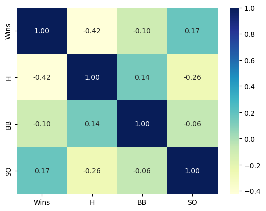

```python
#Visual 2 - FILL IN
correlation = wins_and_pitching[['Wins','H','BB','SO']].corr()
sns.heatmap(correlation, annot=True, fmt=".2f", cmap='YlGnBu')
plt.show()
```

*Answer to research question:* The heatmat supports the conclusions reached by the box plots.

### **5.2:** Reflection

In 2-4 sentences, if you had more time to complete the project, what actions would you take? For example, which data quality and structural issues would you look into further, and what research questions would you further explore?

*Answer:* The first step would be to expand the study by adding more statistics and teams, as it is possible that the Mets' coaching philosophies result in the correlations found. After that, I can begin more research into whether or not there is causation with the stats.